# Final Draft: "Separating Good from Great: Analyzing the Impact of Separation on an Individual NFL Receiver Success"

- Dylan Johnson
- April 30th, 2023
- DA401, Dr. Lavin

# Average Separation (SEP): The distance (in yards) measured between a WR/TE and the nearest defender at the time of catch or incompletion.

# STEP 1: COMBINE DATASETS

Done Manually

# STEP 2: IMPORT, ADAPT, AND PRINT DATA

```python
#import packages
import pandas as pd

# read in the CSV file
df = pd.read_csv('NFL_DATA.csv')

# drop rows with all missing values
df.dropna(axis=0, how='all', inplace=True)

# drop columns with all missing values
df.dropna(axis=1, how='all', inplace=True)

# print the resulting dataframe
print(df)
```

```
          PLAYER NAME TEAM POS  CUSH  SEP   TAY   TAY%    REC    TAR  CTCH%  \
0    Justin Jefferson  MIN  WR   5.4  3.1  10.3  39.03  128.0  184.0  69.57
1         Tyreek Hill  MIA  WR   6.4  3.3  12.2  40.15  119.0  170.0  70.00
2       Davante Adams   LV  WR   5.6  2.9  12.1  41.77  100.0  180.0  55.56
3          A.J. Brown  PHI  WR   5.6  2.6  12.2  41.31   88.0  145.0  60.69
4        Stefon Diggs  BUF  WR   5.4  2.8  11.6  34.57  108.0  154.0  70.13
..                ...  ...  ..   ...  ...   ...    ...    ...    ...    ...
626       Zach Pascal  IND  WR   5.7  2.4   9.6   8.95   27.0   46.0  58.70
627      Ryan Switzer  PIT  WR   5.8  3.5   3.2   2.67   36.0   44.0  81.82
628  DaeSean Hamilton  DEN  WR   5.3  3.1   8.4   8.83   30.0   46.0  65.22
629         John Ross  CIN  WR   5.4  2.2  14.0  18.36   21.0   58.0  36.21
630     Chad Williams  ARI  WR   5.4  1.9  13.2  15.34   17.0   46.0  36.96

        YDS    TD  YAC/R  xYAC/R  +/-    YEAR
0    1809.0   8.0    5.0     4.1  0.9  2022.0
1    1710.0   7.0    4.3     4.1  0.2  2022.0
2    1516.0  14.0    5.2     4.6  0.6  2022.0
3    1496.0  11.0    6.6     4.6  2.0  2022.0
4    1429.0  11.0    4.1     3.4  0.8  2022.0
..      ...   ...    ...     ...  ...     ...
626   268.0   2.0    3.1     3.7 -0.6  2018.0
627   253.0   1.0    4.1     4.6 -0.5  2018.0
628   243.0   2.0    2.4     3.0 -0.6  2018.0
629   210.0   7.0    3.1     3.1  0.0  2018.0
630   171.0   1.0    0.9     1.8 -0.9  2018.0

[631 rows x 16 columns]
```

```python
import os

# Get the current working directory
cwd = os.getcwd()

# Specify the name of your dataset file
data = "my_dataset.csv"

# Construct the full path to your dataset file
dataset_path = os.path.join(cwd, data)

# Print the path of your dataset file
print("Dataset path:", dataset_path)
```

```
Dataset path: /Users/dylanjohnson/Desktop/DA 401/my_dataset.csv
```

```python
# boolean indexing to remove players with "TE" in "POS" column
data = df[df['POS'] != 'TE']

# print the resulting DataFrame
print(data)
```

```
          PLAYER NAME TEAM POS  CUSH  SEP   TAY   TAY%    REC    TAR  CTCH%  \
0    Justin Jefferson  MIN  WR   5.4  3.1  10.3  39.03  128.0  184.0  69.57
1         Tyreek Hill  MIA  WR   6.4  3.3  12.2  40.15  119.0  170.0  70.00
2       Davante Adams   LV  WR   5.6  2.9  12.1  41.77  100.0  180.0  55.56
3          A.J. Brown  PHI  WR   5.6  2.6  12.2  41.31   88.0  145.0  60.69
4        Stefon Diggs  BUF  WR   5.4  2.8  11.6  34.57  108.0  154.0  70.13
..                ...  ...  ..   ...  ...   ...    ...    ...    ...    ...
626       Zach Pascal  IND  WR   5.7  2.4   9.6   8.95   27.0   46.0  58.70
627      Ryan Switzer  PIT  WR   5.8  3.5   3.2   2.67   36.0   44.0  81.82
628  DaeSean Hamilton  DEN  WR   5.3  3.1   8.4   8.83   30.0   46.0  65.22
629         John Ross  CIN  WR   5.4  2.2  14.0  18.36   21.0   58.0  36.21
630     Chad Williams  ARI  WR   5.4  1.9  13.2  15.34   17.0   46.0  36.96

        YDS    TD  YAC/R  xYAC/R  +/-    YEAR
0    1809.0   8.0    5.0     4.1  0.9  2022.0
1    1710.0   7.0    4.3     4.1  0.2  2022.0
2    1516.0  14.0    5.2     4.6  0.6  2022.0
3    1496.0  11.0    6.6     4.6  2.0  2022.0
4    1429.0  11.0    4.1     3.4  0.8  2022.0
..      ...   ...    ...     ...  ...     ...
626   268.0   2.0    3.1     3.7 -0.6  2018.0
627   253.0   1.0    4.1     4.6 -0.5  2018.0
628   243.0   2.0    2.4     3.0 -0.6  2018.0
629   210.0   7.0    3.1     3.1  0.0  2018.0
630   171.0   1.0    0.9     1.8 -0.9  2018.0

[478 rows x 16 columns]
```

# STEP 3: REGRESSION ANALYSIS

First I want to look at the regression analysis of the recievers Separation in comparison to the columns that can be related to success.

```python
import statsmodels.api as sm

# Define the dependent variable
y = data['SEP']

# Define the independent variables
X = data[['TAY', 'TAY%', 'REC', 'TAR', 'CTCH%', 'YDS', 'TD', 'YAC/R', 'xYAC/R', '+/-']]

# Add a constant term to the independent variables
X = sm.add_constant(X)

# Fit the linear regression model
model = sm.OLS(y, X).fit()

# Print the regression results
print(model.summary())
```

```
                            OLS Regression Results
==============================================================================
Dep. Variable:                    SEP   R-squared:                       0.570
Model:                            OLS   Adj. R-squared:                  0.561
Method:                 Least Squares   F-statistic:                     61.83
Date:                Sun, 30 Apr 2023   Prob (F-statistic):           4.17e-79
Time:                        23:56:10   Log-Likelihood:                -127.68
No. Observations:                 478   AIC:                             277.4
Df Residuals:                     467   BIC:                             323.2
Df Model:                          10
Covariance Type:            nonrobust
==============================================================================
                 coef    std err          t      P>|t|      [0.025      0.975]
------------------------------------------------------------------------------
const          0.3448      0.447      0.772      0.441      -0.533       1.223
TAY           -0.0052      0.012     -0.425      0.671      -0.029       0.019
TAY%          -0.0048      0.005     -1.032      0.302      -0.014       0.004
REC           -0.0031      0.006     -0.504      0.614      -0.015       0.009
TAR            0.0093      0.004      2.141      0.033       0.001       0.018
CTCH%          0.0280      0.006      4.965      0.000       0.017       0.039
YDS           -0.0010      0.000     -4.596      0.000      -0.001      -0.001
TD             0.0074      0.007      1.018      0.309      -0.007       0.022
YAC/R          0.5681      0.294      1.935      0.054      -0.009       1.145
xYAC/R        -0.3236      0.294     -1.099      0.272      -0.902       0.255
+/-           -0.5719      0.293     -1.953      0.051      -1.147       0.003
==============================================================================
Omnibus:                        8.355   Durbin-Watson:                   1.864
Prob(Omnibus):                  0.015   Jarque-Bera (JB):                8.439
Skew:                           0.278   Prob(JB):                       0.0147
Kurtosis:                       3.339   Cond. No.                     2.79e+04
==============================================================================

Notes:
[1] Standard Errors assume that the covariance matrix of the errors is correctly specified.
[2] The condition number is large, 2.79e+04. This might indicate that there are
strong multicollinearity or other numerical problems.
```

The sm.OLS() function is used to fit a linear regression model to the data, and the model.summary() method is used to print a summary of the regression results. You can modify the code to analyze different performance metrics or to include additional independent variables if desired.

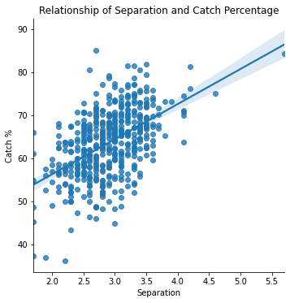

```python
import seaborn as sns
import matplotlib.pyplot as plt

# Set a colorful palette
palette = sns.color_palette("pastel", 10)

# Create partial regression plots for TAR and CTCH%
graph = sns.pairplot(data, x_vars=['SEP'], y_vars=['CTCH%'], kind='reg', height=5, palette=palette)

# Add title and axis labels to the graph
graph.set(title='Relationship of Separation and Catch Percentage', xlabel='Separation', ylabel='Catch %')

# Display the graph
plt.show()
```

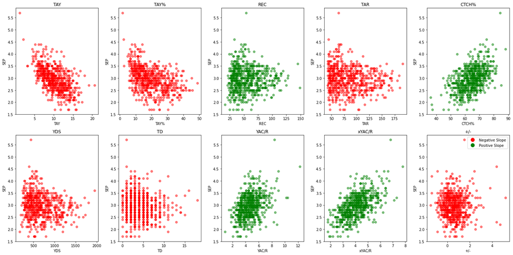

```python
import matplotlib.pyplot as plt
import numpy as np

# define the independent and dependent variables
x_var = 'SEP'
y_vars = ['TAY', 'TAY%', 'REC', 'TAR', 'CTCH%', 'YDS', 'TD', 'YAC/R', 'xYAC/R', '+/-']

# create subplots for each dependent variable
fig, axes = plt.subplots(nrows=2, ncols=5, figsize=(20, 10))
axes = axes.ravel()

# loop through each dependent variable and create a scatter plot
for i, y_var in enumerate(y_vars):
    # set the dot color based on the slope of the regression line
    slope, intercept = np.polyfit(df[y_var], df[x_var], 1)
    if slope < 0:
        dot_color = 'red'
    else:
        dot_color = 'green'
    axes[i].scatter(df[y_var], df[x_var], alpha=0.5, color=dot_color)
    axes[i].set_xlabel(y_var)
    axes[i].set_ylabel(x_var)
    axes[i].set_title(y_var)

# add a legend to explain the colors
red_patch = plt.plot([],[], marker='o', color='red', linestyle='', markersize=10, label='Negative Slope')
green_patch = plt.plot([],[], marker='o', color='green', linestyle='', markersize=10, label='Positive Slope')
plt.legend(handles=[red_patch[0], green_patch[0]])

# adjust spacing between subplots and display the plot
plt.tight_layout()
plt.show()
```

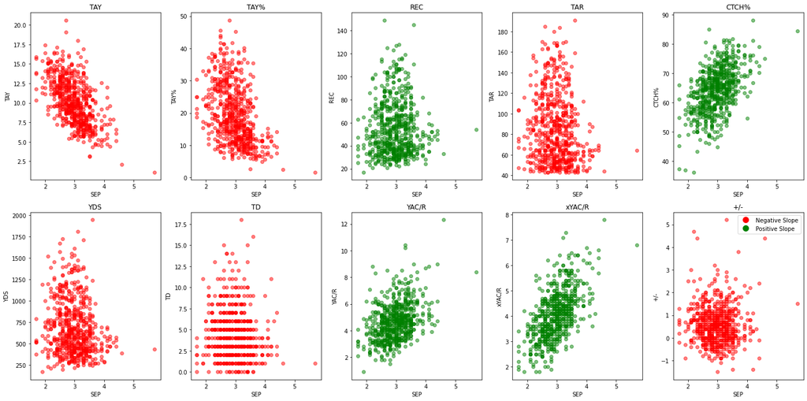

```python
import matplotlib.pyplot as plt
import numpy as np

# define the independent and dependent variables
x_var = 'SEP'
y_vars = ['TAY', 'TAY%', 'REC', 'TAR', 'CTCH%', 'YDS', 'TD', 'YAC/R', 'xYAC/R', '+/-']

# create subplots for each dependent variable
fig, axes = plt.subplots(nrows=2, ncols=5, figsize=(20, 10))
axes = axes.ravel()

# loop through each dependent variable and create a scatter plot
for i, y_var in enumerate(y_vars):
    # set the dot color based on the slope of the regression line
    slope, intercept = np.polyfit(df[x_var], df[y_var], 1)
    if slope < 0:
        dot_color = 'red'
    else:
        dot_color = 'green'
    axes[i].scatter(df[x_var], df[y_var], alpha=0.5, color=dot_color)
    axes[i].set_xlabel(x_var)
    axes[i].set_ylabel(y_var)
    axes[i].set_title(y_var)

# add a legend to explain the colors
red_patch = plt.plot([],[], marker='o', color='red', linestyle='', markersize=10, label='Negative Slope')
green_patch = plt.plot([],[], marker='o', color='green', linestyle='', markersize=10, label='Positive Slope')
plt.legend(handles=[red_patch[0], green_patch[0]])

# adjust spacing between subplots and display the plot
plt.tight_layout()
plt.show()
```

# Results: From our regression analysis, we can pick out the variables that are significantly related to Separation, in order to further my analysis.

# STEP 4: Create new dataset with only needed variables

```python
# Select the required columns to create new dataset
columns = ["PLAYER NAME", "SEP", "CTCH%", "YDS", "TAR", "YEAR"]
selected_data = data[columns]
selected_data
```

|  | PLAYER NAME | SEP | CTCH% | YDS | TAR | YEAR |
| --- | --- | --- | --- | --- | --- | --- |
| 0 | Justin Jefferson | 3.1 | 69.57 | 1809.0 | 184.0 | 2022.0 |
| 1 | Tyreek Hill | 3.3 | 70.00 | 1710.0 | 170.0 | 2022.0 |
| 2 | Davante Adams | 2.9 | 55.56 | 1516.0 | 180.0 | 2022.0 |
| 3 | A.J. Brown | 2.6 | 60.69 | 1496.0 | 145.0 | 2022.0 |
| 4 | Stefon Diggs | 2.8 | 70.13 | 1429.0 | 154.0 | 2022.0 |
| ... | ... | ... | ... | ... | ... | ... |
| 626 | Zach Pascal | 2.4 | 58.70 | 268.0 | 46.0 | 2018.0 |
| 627 | Ryan Switzer | 3.5 | 81.82 | 253.0 | 44.0 | 2018.0 |
| 628 | DaeSean Hamilton | 3.1 | 65.22 | 243.0 | 46.0 | 2018.0 |
| 629 | John Ross | 2.2 | 36.21 | 210.0 | 58.0 | 2018.0 |
| 630 | Chad Williams | 1.9 | 36.96 | 171.0 | 46.0 | 2018.0 |

478 rows × 6 columns

# STEP 5: Analyze NFL: CTCH%, YDS, and TAR

These were the most significant in regression analysis

```python
# Calculate the averages
#To avoid outliers straying the data, i will get the medians as opposed to averages
medians = selected_data.median()

print(medians)
```

```
SEP         2.9
CTCH%      64.0
YDS       656.0
TAR        82.0
YEAR     2020.0
dtype: float64
```

# STEP 6: Explore: Filter Data to see how many "successfull" recievers are above medians

# A. Above Average Seperation

```python
# Select the players with SEP above 2.964659
best_Sep = selected_data[selected_data["SEP"] > 2.9]
best_Sep.sort_values(by=["SEP"], ascending=False, inplace=True)
print(best_Sep)
```

```
           PLAYER NAME  SEP  CTCH%     YDS    TAR    YEAR
220      Rondale Moore  5.7  84.38   435.0   64.0  2021.0
362       Deebo Samuel  4.6  75.00   391.0   44.0  2020.0
87         Greg Dortch  4.2  81.25   467.0   64.0  2022.0
341  Demarcus Robinson  4.2  76.27   466.0   59.0  2020.0
355        David Moore  4.1  74.47   417.0   47.0  2020.0
..                 ...  ...    ...     ...    ...     ...
273        CeeDee Lamb  3.0  66.67   935.0  111.0  2020.0
260      Brandin Cooks  3.0  68.07  1143.0  119.0  2020.0
249       Stefon Diggs  3.0  76.51  1535.0  166.0  2020.0
432     Danny Amendola  3.0  63.92   678.0   97.0  2019.0
243      Calvin Ridley  3.0  59.62   281.0   52.0  2021.0

[217 rows x 6 columns]
```

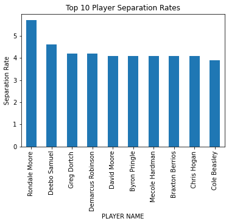

```python
import pandas as pd
import matplotlib.pyplot as plt

# sort by SEP column and select top 10 rows
top_10 = best_Sep.sort_values('SEP', ascending=False).head(10)

# create bar chart
ax = top_10.plot(x='PLAYER NAME', y='SEP', kind='bar', legend=False)
ax.set_ylabel('Separation Rate')
ax.set_title('Top 10 Player Separation Rates')

# display chart
plt.show()
```

# B. Above Average Catch Percentage

```python
# Select the players with SEP above 2.964659
best_Catch = selected_data[selected_data["CTCH%"] > 64]
print(best_Catch)
```

```
          PLAYER NAME  SEP  CTCH%     YDS    TAR    YEAR
0    Justin Jefferson  3.1  69.57  1809.0  184.0  2022.0
1         Tyreek Hill  3.3  70.00  1710.0  170.0  2022.0
4        Stefon Diggs  2.8  70.13  1429.0  154.0  2022.0
5         CeeDee Lamb  3.1  68.59  1359.0  156.0  2022.0
6       Jaylen Waddle  3.0  64.10  1356.0  117.0  2022.0
..                ...  ...    ...     ...    ...     ...
598     Jarius Wright  3.2  72.88   447.0   59.0  2018.0
612        Ryan Grant  2.6  67.31   334.0   52.0  2018.0
621  Laquon Treadwell  2.9  66.04   302.0   53.0  2018.0
627      Ryan Switzer  3.5  81.82   253.0   44.0  2018.0
628  DaeSean Hamilton  3.1  65.22   243.0   46.0  2018.0

[238 rows x 6 columns]
```

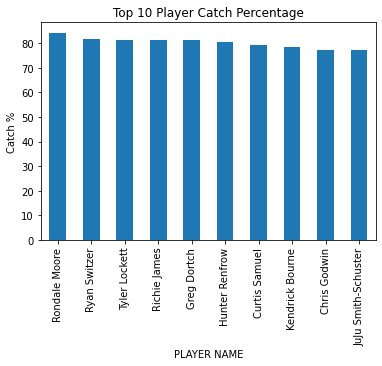

```python
import pandas as pd
import matplotlib.pyplot as plt

# sort by SEP column and select top 10 rows
top_10 = best_Sep.sort_values('CTCH%', ascending=False).head(10)

# create bar chart
ax = top_10.plot(x='PLAYER NAME', y='CTCH%', kind='bar', legend=False)
ax.set_ylabel('Catch %')
ax.set_title('Top 10 Player Catch Percentage')

# display chart
plt.show()
```

# C. Above Average Yards

```python
# Select the players with SEP above 2.964659
best_Yards = selected_data[selected_data["YDS"] > 656]
print(best_Yards)
```

```
          PLAYER NAME  SEP  CTCH%     YDS    TAR    YEAR
0    Justin Jefferson  3.1  69.57  1809.0  184.0  2022.0
1         Tyreek Hill  3.3  70.00  1710.0  170.0  2022.0
2       Davante Adams  2.9  55.56  1516.0  180.0  2022.0
3          A.J. Brown  2.6  60.69  1496.0  145.0  2022.0
4        Stefon Diggs  2.8  70.13  1429.0  154.0  2022.0
..                ...  ...    ...     ...    ...     ...
553    Taylor Gabriel  3.5  72.04   688.0   93.0  2018.0
555  Demaryius Thomas  3.0  66.29   677.0   89.0  2018.0
556    Donte Moncrief  2.2  53.93   672.0   89.0  2018.0
557      Cole Beasley  2.9  74.71   672.0   87.0  2018.0
558     Mike Williams  2.1  65.15   664.0   66.0  2018.0

[236 rows x 6 columns]
```

# D. Above Average Targets

```python
# Select the players with SEP above 2.964659
best_Targets = selected_data[selected_data["TAR"] > 82]
print(best_Targets)
```

```
          PLAYER NAME  SEP  CTCH%     YDS    TAR    YEAR
0    Justin Jefferson  3.1  69.57  1809.0  184.0  2022.0
1         Tyreek Hill  3.3  70.00  1710.0  170.0  2022.0
2       Davante Adams  2.9  55.56  1516.0  180.0  2022.0
3          A.J. Brown  2.6  60.69  1496.0  145.0  2022.0
4        Stefon Diggs  2.8  70.13  1429.0  154.0  2022.0
..                ...  ...    ...     ...    ...     ...
556    Donte Moncrief  2.2  53.93   672.0   89.0  2018.0
557      Cole Beasley  2.9  74.71   672.0   87.0  2018.0
561         Zay Jones  2.8  54.90   652.0  102.0  2018.0
562      Willie Snead  3.1  65.26   651.0   95.0  2018.0
568  Michael Crabtree  2.8  54.00   607.0  100.0  2018.0

[234 rows x 6 columns]
```

```python
import pandas as pd

# Sort the dataframe by "SEP" column in descending order
sorted_success_data = selected_data.sort_values(by='SEP', ascending=False)
# Print the sorted dataframe
print(sorted_success_data)
```

```
           PLAYER NAME  SEP  CTCH%    YDS    TAR    YEAR
220      Rondale Moore  5.7  84.38  435.0   64.0  2021.0
362       Deebo Samuel  4.6  75.00  391.0   44.0  2020.0
87         Greg Dortch  4.2  81.25  467.0   64.0  2022.0
341  Demarcus Robinson  4.2  76.27  466.0   59.0  2020.0
355        David Moore  4.1  74.47  417.0   47.0  2020.0
..                 ...  ...    ...    ...    ...     ...
202     Kenny Golladay  1.7  48.68  521.0   76.0  2021.0
608    Kelvin Benjamin  1.7  37.31  380.0   67.0  2018.0
205     DeVante Parker  1.7  54.79  515.0   73.0  2021.0
69      DeVante Parker  1.7  65.96  539.0   47.0  2022.0
287     DeVante Parker  1.7  61.17  793.0  103.0  2020.0

[478 rows x 6 columns]
```

# Step 7: Eploratory Analysis with Multiple Variables

# 7.1 Above Average in Both Seperation and Catch Percentage

```python
# Select the players with SEP above 2.964659 and CTCH% above 63.538013
# Filter the data based on the given conditions
SEP_CTCH = selected_data[(selected_data["SEP"] > 2.9) & (selected_data["CTCH%"] > 64)]
print(SEP_CTCH)
```

```
           PLAYER NAME  SEP  CTCH%     YDS    TAR    YEAR
0     Justin Jefferson  3.1  69.57  1809.0  184.0  2022.0
1          Tyreek Hill  3.3  70.00  1710.0  170.0  2022.0
5          CeeDee Lamb  3.1  68.59  1359.0  156.0  2022.0
6        Jaylen Waddle  3.0  64.10  1356.0  117.0  2022.0
10   Amon-Ra St. Brown  3.1  72.60  1161.0  146.0  2022.0
..                 ...  ...    ...     ...    ...     ...
594     Chester Rogers  3.6  73.61   485.0   72.0  2018.0
596      Taywan Taylor  3.2  66.07   466.0   56.0  2018.0
598      Jarius Wright  3.2  72.88   447.0   59.0  2018.0
627       Ryan Switzer  3.5  81.82   253.0   44.0  2018.0
628   DaeSean Hamilton  3.1  65.22   243.0   46.0  2018.0

[149 rows x 6 columns]
```

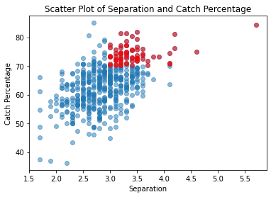

```python
import matplotlib.pyplot as plt

# Filter the data
SEP_CTCH = selected_data[(selected_data["SEP"] > 2.9) & (selected_data["CTCH%"] > 70)]

# Create the scatter plot
plt.scatter(selected_data["SEP"], selected_data["CTCH%"], alpha=0.5)
plt.scatter(SEP_CTCH["SEP"], SEP_CTCH["CTCH%"], color="red", alpha=0.5)

# Add axis labels and title
plt.xlabel("Separation")
plt.ylabel("Catch Percentage")
plt.title("Scatter Plot of Separation and Catch Percentage")

# Show the plot
plt.show()
```

# 7.2 Above Average in Both Seperation and Yards

```python
# Filter the data based on the given conditions
SEP_YDS = selected_data[(selected_data["SEP"] > 2.9) & (selected_data["YDS"] > 656)]
print(SEP_YDS)
```

```
           PLAYER NAME  SEP  CTCH%     YDS    TAR    YEAR
0     Justin Jefferson  3.1  69.57  1809.0  184.0  2022.0
1          Tyreek Hill  3.3  70.00  1710.0  170.0  2022.0
5          CeeDee Lamb  3.1  68.59  1359.0  156.0  2022.0
6        Jaylen Waddle  3.0  64.10  1356.0  117.0  2022.0
10   Amon-Ra St. Brown  3.1  72.60  1161.0  146.0  2022.0
..                 ...  ...    ...     ...    ...     ...
539        Golden Tate  3.0  65.49   789.0  113.0  2018.0
545     Nelson Agholor  3.4  65.98   743.0   97.0  2018.0
550     Dede Westbrook  3.5  65.35   715.0  101.0  2018.0
553     Taylor Gabriel  3.5  72.04   688.0   93.0  2018.0
555   Demaryius Thomas  3.0  66.29   677.0   89.0  2018.0

[93 rows x 6 columns]
```

[figure not shown]

```python
import matplotlib.pyplot as plt

# Filter the data
SEP_TAR = selected_data[(selected_data["SEP"] > 2.9) & (selected_data["TAR"] > 63)]

# Create the scatter plot
plt.scatter(selected_data["SEP"], selected_data["YDS"], alpha=0.5)
plt.scatter(SEP_TAR["SEP"], SEP_TAR["YDS"], color="red", alpha=0.5)

# Add axis labels and title
plt.xlabel("Separation")
plt.ylabel("Yards per Catch")
plt.title("Scatter Plot of Separation and Yards Per Catch")

# Show the plot
plt.show()
```

# 7.3 Exploratory: Above Average in Both Seperation and Targets

```python
SEP_TAR = selected_data[(selected_data["SEP"] > 2.9) & (selected_data["TAR"] > 82)]
print(SEP_TAR)
```

```
           PLAYER NAME  SEP  CTCH%     YDS    TAR    YEAR
0     Justin Jefferson  3.1  69.57  1809.0  184.0  2022.0
1          Tyreek Hill  3.3  70.00  1710.0  170.0  2022.0
5          CeeDee Lamb  3.1  68.59  1359.0  156.0  2022.0
6        Jaylen Waddle  3.0  64.10  1356.0  117.0  2022.0
10   Amon-Ra St. Brown  3.1  72.60  1161.0  146.0  2022.0
..                 ...  ...    ...     ...    ...     ...
545     Nelson Agholor  3.4  65.98   743.0   97.0  2018.0
550     Dede Westbrook  3.5  65.35   715.0  101.0  2018.0
553     Taylor Gabriel  3.5  72.04   688.0   93.0  2018.0
555   Demaryius Thomas  3.0  66.29   677.0   89.0  2018.0
562       Willie Snead  3.1  65.26   651.0   95.0  2018.0

[98 rows x 6 columns]
```

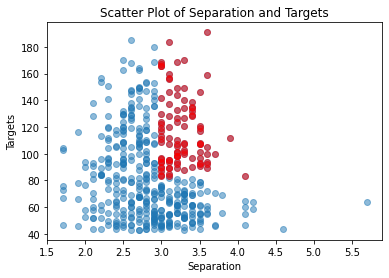

```python
import matplotlib.pyplot as plt

# Create the scatter plot
plt.scatter(selected_data["SEP"], selected_data["TAR"], alpha=0.5)
plt.scatter(SEP_TAR["SEP"], SEP_TAR["TAR"], color="red", alpha=0.5)

# Add axis labels and title
plt.xlabel("Separation")
plt.ylabel("Targets")
plt.title("Scatter Plot of Separation and Targets")

# Show the plot
plt.show()
```

# 7.4 Exploratory: Above Average in ALL Seperation, Catch Percentage, Yards, and Targets

```python
# Filter the data based on the given conditions
successful_wrs = selected_data[(selected_data["SEP"] > 2.9) & (selected_data["CTCH%"] > 64) & (selected_data["YDS"] > 656) & (selected_data["TAR"] > 82)]

print(successful_wrs)
```

```
           PLAYER NAME  SEP  CTCH%     YDS    TAR    YEAR
0     Justin Jefferson  3.1  69.57  1809.0  184.0  2022.0
1          Tyreek Hill  3.3  70.00  1710.0  170.0  2022.0
5          CeeDee Lamb  3.1  68.59  1359.0  156.0  2022.0
6        Jaylen Waddle  3.0  64.10  1356.0  117.0  2022.0
10   Amon-Ra St. Brown  3.1  72.60  1161.0  146.0  2022.0
..                 ...  ...    ...     ...    ...     ...
539        Golden Tate  3.0  65.49   789.0  113.0  2018.0
545     Nelson Agholor  3.4  65.98   743.0   97.0  2018.0
550     Dede Westbrook  3.5  65.35   715.0  101.0  2018.0
553     Taylor Gabriel  3.5  72.04   688.0   93.0  2018.0
555   Demaryius Thomas  3.0  66.29   677.0   89.0  2018.0

[68 rows x 6 columns]
```

```python
#Sort data
successful_wrs = selected_data[(selected_data["SEP"] > 2.9) & (selected_data["CTCH%"] > 64) & (selected_data["YDS"] > 656) & (selected_data["TAR"] > 82)]
sorted_wrs = successful_wrs.sort_values(by="YDS", ascending=False)
print(sorted_wrs)
```

```
          PLAYER NAME  SEP  CTCH%     YDS    TAR    YEAR
122       Cooper Kupp  3.6  75.92  1947.0  191.0  2021.0
0    Justin Jefferson  3.1  69.57  1809.0  184.0  2022.0
1         Tyreek Hill  3.3  70.00  1710.0  170.0  2022.0
123  Justin Jefferson  3.0  64.67  1616.0  167.0  2021.0
249      Stefon Diggs  3.0  76.51  1535.0  166.0  2020.0
..                ...  ...    ...     ...    ...     ...
173    Mecole Hardman  4.1  71.08   693.0   83.0  2021.0
553    Taylor Gabriel  3.5  72.04   688.0   93.0  2018.0
431   Diontae Johnson  3.6  64.13   680.0   92.0  2019.0
555  Demaryius Thomas  3.0  66.29   677.0   89.0  2018.0
436    Dede Westbrook  3.2  65.35   660.0  101.0  2019.0

[68 rows x 6 columns]
```

```python
#import pandas as pd

best_wrs = pd.DataFrame(sorted_wrs)

# drop rows with repeated names
best_wrs.drop_duplicates(subset=['PLAYER NAME'], inplace=True)

print(best_wrs)
```

```
             PLAYER NAME  SEP  CTCH%     YDS    TAR    YEAR
122          Cooper Kupp  3.6  75.92  1947.0  191.0  2021.0
0       Justin Jefferson  3.1  69.57  1809.0  184.0  2022.0
1            Tyreek Hill  3.3  70.00  1710.0  170.0  2022.0
249         Stefon Diggs  3.0  76.51  1535.0  166.0  2020.0
251      DeAndre Hopkins  3.1  71.88  1407.0  160.0  2020.0
511        Davante Adams  3.0  65.68  1386.0  169.0  2018.0
512  JuJu Smith-Schuster  3.0  66.87  1383.0  166.0  2018.0
5            CeeDee Lamb  3.1  68.59  1359.0  156.0  2022.0
6          Jaylen Waddle  3.0  64.10  1356.0  117.0  2022.0
518         Robert Woods  3.0  66.15  1219.0  130.0  2018.0
130        Tyler Lockett  3.2  68.22  1175.0  107.0  2021.0
10     Amon-Ra St. Brown  3.1  72.60  1161.0  146.0  2022.0
260        Brandin Cooks  3.0  68.07  1143.0  119.0  2020.0
134         Keenan Allen  3.1  67.52  1138.0  157.0  2021.0
```

[output cut: 28 more lines]

```python
# Calculate the averages
#To avoid outliers straying the data, i will get the medians as opposed to averages
median2 = best_wrs.median()

print(median2)
```

```
SEP         3.20
CTCH%      69.57
YDS       850.50
TAR       107.00
YEAR     2020.00
dtype: float64
```

```python
#remove duplicates to remove any players who have met ALL requirements twice
num_rows = len(best_wrs)

print(num_rows)
```

```
42
```

WHY USE ALL: I am proceeding with the 68 players who met all requirements met because I am looking for Separation's relation to success. Therefore, I want to look at the recievers who have excelled more than most in every category. For this method, we consider that "success" in the NFL includes being above average in all four of our significantly related statistics: Separation, Catch Percentage, Receiving Yards, and Targets. aspect that is valuable to my analysis. we can assume that these players are successful.

# Step 8: Time Series Analysis

```python
import pandas as pd

# group the data by player name
groups = sorted_wrs.groupby("PLAYER NAME")

# iterate through each group and calculate the difference for each year
for player, group in groups:
    print(f"Player: {player}")
    prev_year = None
    for index, row in group.iterrows():
        if prev_year is not None:
            year_diff = row["YEAR"] - prev_year["YEAR"]
            sep_diff = row["SEP"] - prev_year["SEP"]
            ctch_diff = row["CTCH%"] - prev_year["CTCH%"]
            yds_diff = row["YDS"] - prev_year["YDS"]
            tar_diff = row["TAR"] - prev_year["TAR"]
            print(f"  Year: {row['YEAR']} \t SEP diff: {sep_diff:+5.2f} \t CTCH% diff: {ctch_diff:+5.2f} \t YDS diff: {yds_diff:+5.2f} \t TAR diff: {tar_diff:+5.2f}")
        prev_year = row
```

```
Player: Adam Humphries
Player: Adam Thielen
Player: Amon-Ra St. Brown
  Year: 2021.0 	 SEP diff: +0.40 	 CTCH% diff: +3.03 	 YDS diff: -249.00 	 TAR diff: -27.00
Player: Brandin Cooks
  Year: 2021.0 	 SEP diff: +0.30 	 CTCH% diff: -0.91 	 YDS diff: -115.00 	 TAR diff: +15.00
Player: Calvin Ridley
Player: CeeDee Lamb
  Year: 2021.0 	 SEP diff: +0.00 	 CTCH% diff: -2.76 	 YDS diff: -257.00 	 TAR diff: -36.00
  Year: 2020.0 	 SEP diff: -0.10 	 CTCH% diff: +0.84 	 YDS diff: -167.00 	 TAR diff: -9.00
Player: Chris Godwin
  Year: 2022.0 	 SEP diff: -0.30 	 CTCH% diff: -3.93 	 YDS diff: -84.00 	 TAR diff: +15.00
  Year: 2020.0 	 SEP diff: +0.00 	 CTCH% diff: +4.14 	 YDS diff: -179.00 	 TAR diff: -58.00
Player: Christian Kirk
Player: Cole Beasley
  Year: 2021.0 	 SEP diff: +0.40 	 CTCH% diff: -3.43 	 YDS diff: -274.00 	 TAR diff: +5.00
Player: Cooper Kupp
  Year: 2019.0 	 SEP diff: -0.20 	 CTCH% diff: -5.77 	 YDS diff: -786.00 	 TAR diff: -57.00
  Year: 2020.0 	 SEP diff: -0.20 	 CTCH% diff: +4.04 	 YDS diff: -187.00 	 TAR diff: -10.00
  Year: 2022.0 	 SEP diff: +0.00 	 CTCH% diff: +2.34 	 YDS diff: -162.00 	 TAR diff: -26.00
Player: Curtis Samuel
Player: Davante Adams
  Year: 2020.0 	 SEP diff: +0.20 	 CTCH% diff: +11.50 	 YDS diff: -12.00 	 TAR diff: -20.00
  Year: 2019.0 	 SEP diff: +0.00 	 CTCH% diff: -11.83 	 YDS diff: -377.00 	 TAR diff: -22.00
Player: DeAndre Hopkins
Player: Dede Westbrook
  Year: 2019.0 	 SEP diff: -0.30 	 CTCH% diff: +0.00 	 YDS diff: -55.00 	 TAR diff: +0.00
Player: Demaryius Thomas
Player: Diontae Johnson
Player: Emmanuel Sanders
Player: Golden Tate
Player: Hunter Renfrow
Player: Jakobi Meyers
Player: Jamison Crowder
Player: Jarvis Landry
Player: Jaylen Waddle
  Year: 2021.0 	 SEP diff: +0.30 	 CTCH% diff: +10.19 	 YDS diff: -341.00 	 TAR diff: +23.00
Player: Jerry Jeudy
Player: Josh Palmer
Player: JuJu Smith-Schuster
```

[output cut: 13 more lines]

```
  Year: 2019.0 	 SEP diff: +0.40 	 CTCH% diff: -1.40 	 YDS diff: -85.00 	 TAR diff: +9.00
  Year: 2020.0 	 SEP diff: +0.00 	 CTCH% diff: +5.02 	 YDS diff: -198.00 	 TAR diff: -10.00
Player: Russell Gage
Player: Stefon Diggs
Player: Taylor Gabriel
Player: Tyler Boyd
Player: Tyler Lockett
  Year: 2019.0 	 SEP diff: +0.00 	 CTCH% diff: +6.33 	 YDS diff: -118.00 	 TAR diff: +3.00
  Year: 2020.0 	 SEP diff: +0.20 	 CTCH% diff: +1.21 	 YDS diff: -3.00 	 TAR diff: +22.00
  Year: 2022.0 	 SEP diff: +0.10 	 CTCH% diff: -3.97 	 YDS diff: -21.00 	 TAR diff: -15.00
Player: Tyreek Hill
  Year: 2020.0 	 SEP diff: +0.10 	 CTCH% diff: -5.56 	 YDS diff: -434.00 	 TAR diff: -35.00
  Year: 2021.0 	 SEP diff: +0.20 	 CTCH% diff: +5.37 	 YDS diff: -37.00 	 TAR diff: +24.00
  Year: 2019.0 	 SEP diff: -0.40 	 CTCH% diff: -4.64 	 YDS diff: -379.00 	 TAR diff: -70.00
Player: Zay Jones
```

```python
#Find players whos statistics have shown the same relations as my model.
# select the relevant columns
df_select = successful_wrs[['PLAYER NAME', 'YEAR', 'SEP', 'CTCH%', 'YDS', 'TAR']]

# group by player name and year
df_grouped = df_select.groupby(['PLAYER NAME', 'YEAR']).mean()

# create a new column 'Increase' which indicates if the player increased in all three categories and decreased in yards
df_grouped['Increase'] = ((df_grouped['SEP'].diff() > 0) & (df_grouped['CTCH%'].diff() > 0) & (df_grouped['TAR'].diff() > 0) & (df_grouped['YDS'].diff() < 0)).astype(int)

# get the players who meet the criteria
increased = df_grouped[df_grouped['Increase'] == 1]

# count the number of players who meet the criteria for each year
count_increase = df_grouped[df_grouped['Increase'] == 1].groupby(['YEAR', 'PLAYER NAME'])['Increase'].count()

print(count_increase)
```

```
YEAR    PLAYER NAME
2020.0  Cole Beasley     1
        Tyler Lockett    1
2021.0  Tyreek Hill      1
2022.0  Tyler Lockett    1
Name: Increase, dtype: int64
```

```python
import matplotlib.pyplot as plt
import pandas as pd

# Create a dataframe to store the data
data1 = pd.DataFrame({
    'Year': [2020.0, 2020.0, 2021.0, 2022.0],
    'Player Name': ['Cole Beasley', 'Tyler Lockett', 'Tyreek Hill', 'Tyler Lockett'],
    'Increase': [1, 1, 1, 1]
})

# Group the data by year and player name
grouped_data = data.groupby(['Year', 'Player Name']).sum()['Increase']

# Create a bar plot to represent the results
grouped_data.plot(kind='bar', figsize=(8,6))
plt.title('Number of Players with Increase in Performance by Year')
plt.xlabel('Year')
plt.ylabel('Number of Players')
plt.show()
```

[output not shown]

# Cluster Analysis

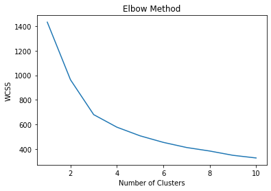

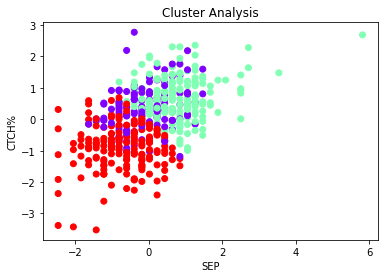

```
              SEP      CTCH%         TAR
Cluster
0        2.829600  66.365440  133.688000
1        3.292398  68.779357   71.918129
2        2.556044  56.671538   71.934066
```

```python
import pandas as pd
from sklearn.cluster import KMeans
import matplotlib.pyplot as plt

# Define variables of interest
X = data[['SEP','CTCH%','TAR']]

# Standardize variables
X = (X - X.mean()) / X.std()

# Determine optimal number of clusters using elbow method
wcss = []
for i in range(1, 11):
    kmeans = KMeans(n_clusters=i, init='k-means++', random_state=42)
    kmeans.fit(X)
    wcss.append(kmeans.inertia_)
plt.plot(range(1, 11), wcss)
plt.title('Elbow Method')
plt.xlabel('Number of Clusters')
plt.ylabel('WCSS')
plt.show()

# Fit k-means clustering model
kmeans = KMeans(n_clusters=3, init='k-means++', random_state=42)
kmeans.fit(X)

# Add cluster labels to data
data['Cluster'] = kmeans.labels_

# Visualize clusters
plt.scatter(X.iloc[:, 0], X.iloc[:, 1], c=kmeans.labels_, cmap='rainbow')
plt.title('Cluster Analysis')
plt.xlabel('SEP')
plt.ylabel('CTCH%')
plt.show()

# Analyze cluster characteristics
cluster_means = data.groupby('Cluster')[['SEP', 'CTCH%', 'TAR']].mean()
print(cluster_means)
```

From this cluster analysis, we can see that across the league, players with higher SEP have a higher CTCH%